# Working_Code_File.Rmd

Brad Kruse

5/24/2020

### Directions

Commit containing full submission

1. Code for reading in the dataset and/or processing the data
2. Histogram of the total number of steps taken each day
3. Mean and median number of steps taken each day
4. Time series plot of the average number of steps taken
5. The 5-minute interval that, on average, contains the maximum number of steps
6. Code to describe and show a strategy for imputing missing data
7. Histogram of the total number of steps taken each day after missing values are imputed
8. Panel plot comparing the average number of steps taken per 5-minute interval across weekdays and weekends
9. All of the R code needed to reproduce the results (numbers, plots, etc.) in the report

### Part 1: Code for reading in the dataset and/or processing the data

```r
fileURL <- "https://d396qusza40orc.cloudfront.net/repdata%2Fdata%2Factivity.zip"
download.file(fileURL, destfile = "Dataset.zip")
unzip("Dataset.zip")
stepsdata <- read.csv("activity.csv", header = TRUE, stringsAsFactors = FALSE)
stepsdata$date <-as.Date(stepsdata$date)
```

#### Examining the characteristics of the imported data file

```r
dim(stepsdata)
```

```
## [1] 17568     3
```

```r
summary(stepsdata)
```

```
##      steps             date               interval
##  Min.   :  0.00   Min.   :2012-10-01   Min.   :   0.0
##  1st Qu.:  0.00   1st Qu.:2012-10-16   1st Qu.: 588.8
##  Median :  0.00   Median :2012-10-31   Median :1177.5
##  Mean   : 37.38   Mean   :2012-10-31   Mean   :1177.5
##  3rd Qu.: 12.00   3rd Qu.:2012-11-15   3rd Qu.:1766.2
##  Max.   :806.00   Max.   :2012-11-30   Max.   :2355.0
##  NA's   :2304
```

```r
head(stepsdata)
```

```
##   steps       date interval
## 1    NA 2012-10-01        0
## 2    NA 2012-10-01        5
## 3    NA 2012-10-01       10
## 4    NA 2012-10-01       15
## 5    NA 2012-10-01       20
## 6    NA 2012-10-01       25
```

### Part 2: Histogram of the total number of steps taken each day

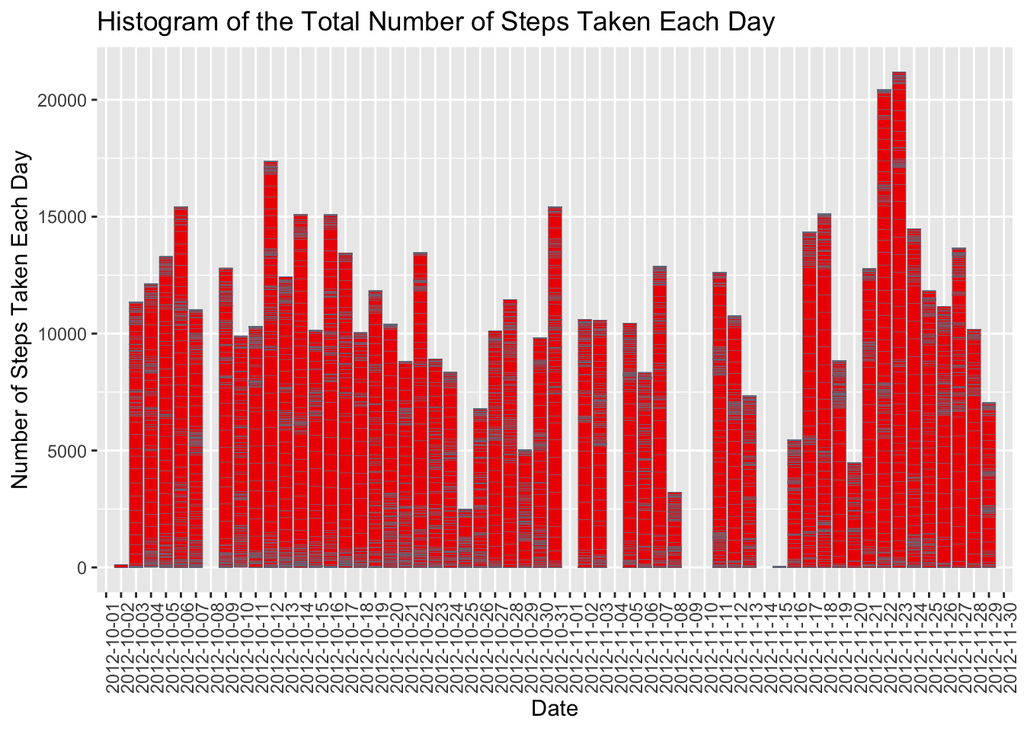

```r
library(ggplot2)
HPlot1 <- ggplot(stepsdata, aes(factor(date), steps), na.rm = TRUE) +
        geom_histogram(binwidth = 2000, fill = "red2", colour = "slategray", size = .1,
        stat = "identity") +
        xlab('Date') +
        ylab('Number of Steps Taken Each Day') +
        theme(axis.text.x = element_text(angle=90, hjust=1, vjust=1)) +
        ggtitle('Histogram of the Total Number of Steps Taken Each Day')
print(HPlot1)
```

### Part 3: Mean and median number of steps taken each day

- The mean number of steps per day is 10766.19 and the median is 10765.

```r
stepsperday <- aggregate(steps~date, stepsdata, FUN = sum)
stepsmean <- mean(stepsperday$steps)
stepsmedian <- median(stepsperday$steps)
round(stepsmean, digits = 2)
```

```
## [1] 10766.19
```

```r
round(stepsmedian, digits = 2)
```

```
## [1] 10765
```

### Part 4: Time series plot of the average number of steps taken

- Line plot showing the average daily activity pattern.

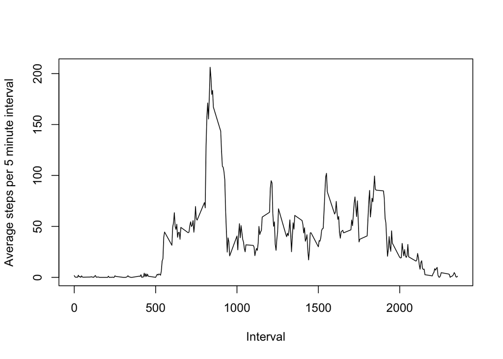

```r
stepsperinterval <- aggregate(steps~interval, stepsdata, FUN = mean)
plot(stepsperinterval$steps~stepsperinterval$interval, type = "l", xlab = "Interval",
     ylab = "Average steps per 5 minute interval")
```

### Part 5: The 5-minute interval that, on average, contains the maximum number of steps

```r
    maxinterval <-stepsperinterval[stepsperinterval$steps==max(stepsperinterval$steps),]
    print(maxinterval)
```

```
##     interval    steps
## 104      835 206.1698
```

### Part 6: Code to describe and show a strategy for imputing missing data

```r
library(mice)
imp_adata <- mice(stepsdata, method = "mean", m = 1, maxit = 1)
bdata <- complete(imp_adata, 1)
steps_imp <- aggregate(steps~date, bdata, FUN = sum)
stepsimpmean <- mean(steps_imp$steps)
stepsimpmedian <- median(steps_imp$steps)
round(stepsimpmean, digits = 2)
```

```
## [1] 10766.19
```

```r
round(stepsimpmedian, digits = 2)
```

```
## [1] 10766.19
```

```r
sum(is.na(stepsdata))
```

```
## [1] 2304
```

### Part 7: Histogram of the total number of steps taken each day after missing values are imputed

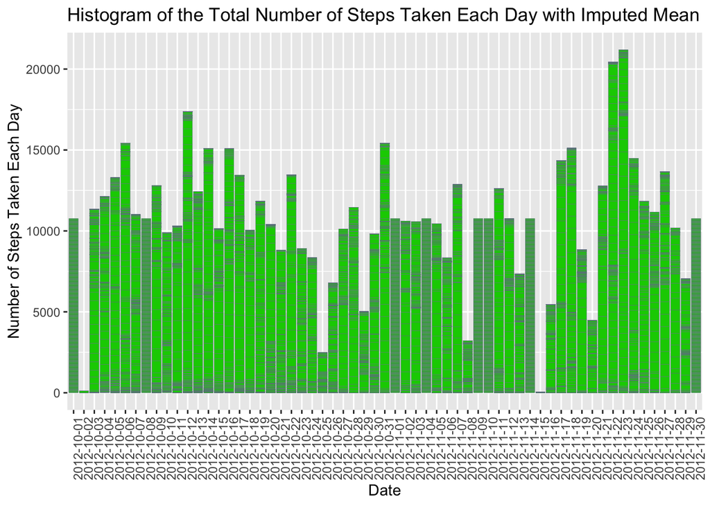

```r
HPlot2 <- ggplot(bdata, aes(factor(date), steps), na.rm = TRUE) +
        geom_histogram(binwidth = 2000, fill = "green3", colour = "slategray", size = .1,
        stat = "identity") +
        xlab('Date') +
        ylab('Number of Steps Taken Each Day') +
        theme(axis.text.x = element_text(angle=90, hjust=1, vjust=1)) +
        ggtitle('Histogram of the Total Number of Steps Taken Each Day with Imputed Mean')
print(HPlot2)
```

### Part 8: Panel plot comparing the average number of steps taken per 5 minute interval across weekdays and weekends

#### Create a new factor variable in the data set with two levels, “weekday” and “weekend”

```r
bdata$date <- as.Date(bdata$date)
weekdays1 <- c('Monday', 'Tuesday', 'Wednesday', 'Thursday', 'Friday')
bdata$wDay <- factor((weekdays(bdata$date) %in% weekdays1),
             levels=c(FALSE, TRUE), labels=c('weekend', 'weekday'))
```

#### Make a panel plot containing a time series plot (i.e. type = “l”) of the 5-minute interval (x-axis) and the average number of steps taken, averaged across all weekday days or weekend days

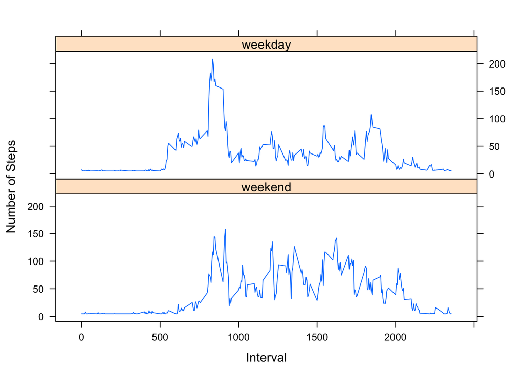

```r
stepsperWdayWend <- aggregate(steps~interval + wDay, bdata, FUN = mean)
library(lattice)
xyplot(steps~interval | factor (wDay),
           data = stepsperWdayWend,
           layout = c(1,2),
           xlab = "Interval",
           ylab = "Number of Steps",
           type = "l")
```